# Machine Learning - Mid-Term Practice

### —————————————————————————-

## Question 1

This problem concerns the **College.rds** dataset which contains statistics for a large number of US Colleges from the 1995 issue of US News and World Report. Load the dataset into your R session using the following code.

```r
College <- readRDS("College.rds")
```

The dataset contains information on the following variables.

- `Private` - A factor with levels ‘No’ and ‘Yes’ indicating private or public university
- `Apps` - Number of applications received
- `Top10perc` - Pct. new students from top 10% of H.S. class
- `Top25perc` - Pct. new students from top 25% of H.S. class
- `F.Undergrad` - Number of full-time undergraduates
- `P.Undergrad` - Number of part-time undergraduates
- `Outstate` - Out-of-state tuition
- `Room.Board` - Room and board costs
- `Books` - Estimated book costs
- `Personal` - Estimated personal spending
- `PhD` - Pct. of faculty with Ph.D.’s
- `Terminal` - Pct. of faculty with terminal degree
- `S.F.Ratio` - Student/faculty ratio
- `perc.alumni` - Pct. alumni who donate
- `Expend` - Instructional expenditure per student
- `Grad.Rate` - Graduation rate
- `Yield` - Percentage of students who choose to enroll in a particular college or university after having been offered admission

Consider `Yield` as the response variable and the rest of the variables as predictors.

Compare the performance (in terms of **RMSE**) of the following two models:

- A linear regression model;
- A $K$-NN regression model with optimal $K$ chosen by CV. Consider the grid of possible $K$ values given below.

**Perform the following tasks.**

- Investigate the dataset and complete any necessary tasks.

```r
summary(College) # all numeric except Private, which is nominal
```

```
##  Private        Apps         Top10perc       Top25perc      F.Undergrad
##  No :212   Min.   :   81   Min.   : 1.00   Min.   :  9.0   Min.   :  139
##  Yes:565   1st Qu.:  776   1st Qu.:15.00   1st Qu.: 41.0   1st Qu.:  992
##            Median : 1558   Median :23.00   Median : 54.0   Median : 1707
##            Mean   : 3002   Mean   :27.56   Mean   : 55.8   Mean   : 3700
##            3rd Qu.: 3624   3rd Qu.:35.00   3rd Qu.: 69.0   3rd Qu.: 4005
##            Max.   :48094   Max.   :96.00   Max.   :100.0   Max.   :31643
##   P.Undergrad         Outstate       Room.Board       Books
##  Min.   :    1.0   Min.   : 2340   Min.   :1780   Min.   :  96.0
##  1st Qu.:   95.0   1st Qu.: 7320   1st Qu.:3597   1st Qu.: 470.0
##  Median :  353.0   Median : 9990   Median :4200   Median : 500.0
##  Mean   :  855.3   Mean   :10441   Mean   :4358   Mean   : 549.4
##  3rd Qu.:  967.0   3rd Qu.:12925   3rd Qu.:5050   3rd Qu.: 600.0
##  Max.   :21836.0   Max.   :21700   Max.   :8124   Max.   :2340.0
##     Personal         PhD            Terminal       S.F.Ratio
##  Min.   : 250   Min.   :  8.00   Min.   : 24.0   Min.   : 2.50
##  1st Qu.: 850   1st Qu.: 62.00   1st Qu.: 71.0   1st Qu.:11.50
##  Median :1200   Median : 75.00   Median : 82.0   Median :13.60
##  Mean   :1341   Mean   : 72.66   Mean   : 79.7   Mean   :14.09
##  3rd Qu.:1700   3rd Qu.: 85.00   3rd Qu.: 92.0   3rd Qu.:16.50
##  Max.   :6800   Max.   :103.00   Max.   :100.0   Max.   :39.80
##   perc.alumni        Expend        Grad.Rate          Yield
##  Min.   : 0.00   Min.   : 3186   Min.   : 10.00   Min.   :  9.975
##  1st Qu.:13.00   1st Qu.: 6751   1st Qu.: 53.00   1st Qu.: 31.720
##  Median :21.00   Median : 8377   Median : 65.00   Median : 38.742
##  Mean   :22.74   Mean   : 9660   Mean   : 65.46   Mean   : 41.201
##  3rd Qu.:31.00   3rd Qu.:10830   3rd Qu.: 78.00   3rd Qu.: 48.567
##  Max.   :64.00   Max.   :56233   Max.   :118.00   Max.   :100.000
```

```r
sum(is.na(College)) # no NA variables
```

```
## [1] 0
```

```r
nearZeroVar(College, saveMetrics = TRUE)   # check which predictors are zv/nzv, so yay there are none
```

```
##             freqRatio percentUnique zeroVar   nzv
## Private      2.665094     0.2574003   FALSE FALSE
## Apps         1.000000    91.5057915   FALSE FALSE
## Top10perc    1.057143    10.5534106   FALSE FALSE
## Top25perc    1.000000    11.4543115   FALSE FALSE
## F.Undergrad  1.000000    91.8918919   FALSE FALSE
## P.Undergrad  1.166667    72.8442728   FALSE FALSE
## Outstate     2.600000    82.3680824   FALSE FALSE
## Room.Board   1.285714    71.1711712   FALSE FALSE
## Books        1.390625    15.7014157   FALSE FALSE
## Personal     1.363636    37.8378378   FALSE FALSE
## PhD          1.083333    10.0386100   FALSE FALSE
## Terminal     1.034483     8.3655084   FALSE FALSE
## S.F.Ratio    1.071429    22.2651223   FALSE FALSE
## perc.alumni  1.032258     7.8507079   FALSE FALSE
## Expend       1.000000    95.7528958   FALSE FALSE
## Grad.Rate    1.043478    10.4247104   FALSE FALSE
## Yield        1.000000    99.7425997   FALSE FALSE
```

- Split the data into training and test sets (80-20).

```r
set.seed(333)
# create partition
ti <- createDataPartition(y = College$Yield, p = 0.8, list = FALSE)

# train and test
college_train <- College[ti,]
college_test <- College[-ti,]
```

- Perform required data preprocessing and create the blueprint. If using `step_dummy()`, set `one_hot = FALSE`. Prepare the blueprint on the training data. Obtain the modified training and test datasets. **Explain the blueprint steps that you use.**

```r
set.seed(333)

# prep the recipe
college_recipe <- recipe(Yield ~ ., data = college_train)

# create blueprint by using the step_center to center all numeric, the step_scale to scale all numeric, and the step_dummy to convert categorical variables (literally only the yes/no one (Private) and exclude response).
blueprint <- college_recipe %>%
  step_center(all_numeric(), -all_outcomes()) %>%
  step_scale(all_numeric(), -all_outcomes()) %>%
  step_dummy(all_nominal(), one_hot = FALSE)

# prepare and apply blueprint to test and training data
prepare <- prep(blueprint, data = college_train)
baked_train <- bake(prepare, new_data = college_train)
baked_test <- bake(prepare, new_data = college_test)
```

- Implement 5-fold CV repeated 5 times for each of the models above.

```r
set.seed(333)

# cv stuff
cv_specs <- trainControl(method = "repeatedcv", number = 5, repeats = 5)

# lm stuff
lm_fit <- train(blueprint,
                  data = college_train,
                  method = "lm",
                  trControl = cv_specs,
                  metric = "RMSE")

# knn stuff
k_grid <- expand.grid(k = seq(1, 101, by = 10))
knn_fit <- train(blueprint,
                  data = college_train,
                  method = "knn",
                  trControl = cv_specs,
                  tuneGrid = k_grid,
                  metric = "RMSE")

# full cv results on lm and knn, best k, optimal RMSE, and plot the graph
lm_fit # full cv results
```

```
## Linear Regression
##
## 624 samples
##  16 predictor
##
## Recipe steps: center, scale, dummy
## Resampling: Cross-Validated (5 fold, repeated 5 times)
## Summary of sample sizes: 500, 500, 499, 498, 499, 500, ...
## Resampling results:
##
##   RMSE     Rsquared   MAE
##   10.5323  0.3557933  7.936031
##
## Tuning parameter 'intercept' was held constant at a value of TRUE
```

```r
knn_fit # full cv results
```

```
## k-Nearest Neighbors
##
## 624 samples
##  16 predictor
##
## Recipe steps: center, scale, dummy
## Resampling: Cross-Validated (5 fold, repeated 5 times)
## Summary of sample sizes: 499, 499, 500, 499, 499, 500, ...
## Resampling results across tuning parameters:
##
##   k    RMSE      Rsquared   MAE
##     1  13.97309  0.1692033  10.674002
##    11  10.71847  0.3217738   8.139145
##    21  10.66933  0.3387564   8.114416
##    31  10.65040  0.3493491   8.124013
##    41  10.80565  0.3317748   8.229144
##    51  10.86969  0.3295806   8.267270
##    61  10.99810  0.3143396   8.345977
##    71  11.05556  0.3081673   8.395171
##    81  11.11150  0.3023311   8.441206
##    91  11.16840  0.2955635   8.484948
##   101  11.21305  0.2906590   8.524435
##
## RMSE was used to select the optimal model using the smallest value.
## The final value used for the model was k = 31.
```

```r
knn_fit$bestTune$k # best k value
```

```
## [1] 31
```

```r
min(knn_fit$results$RMSE) # optimal RMSE
```

```
## [1] 10.6504
```

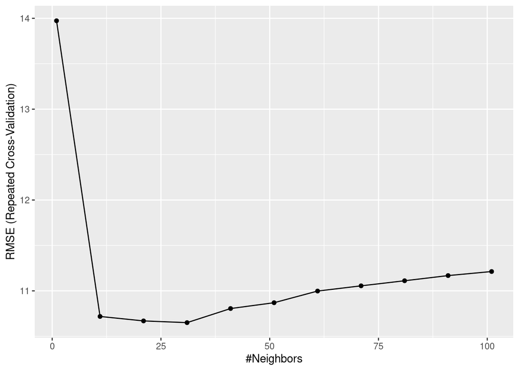

```r
ggplot(knn_fit) # plot it
```

- Report the optimal CV RMSE of each model. Report the optimal value of $K$ for the $K$-NN model. Which model performs better in this situation?

```r
# best optimal CV RMSE for LM
lm_fit$results$RMSE
```

```
## [1] 10.5323
```

```r
# best optimal CV RMSE for KNN:
min(knn_fit$results$RMSE)
```

```
## [1] 10.6504
```

```r
# k for knn
knn_fit$bestTune$k
```

```
## [1] 31
```

```
lm_fit performs better because the RMSE is smaller
```

- Using the optimal model, obtain predictions on the test set. Calculate and report the test set RMSE.

```r
# build final model, get predictions on test data, and calculate test RMSE
final_model <- lm(Yield ~  ., data = baked_train)
final_preds <- predict(object = final_model, newdata = baked_test)
sqrt(mean((final_preds - baked_test$Yield)^2))
```

```
## [1] 13.13224
```

- Using the CV object for the linear regression model, obtain the variable importance measures for each feature.

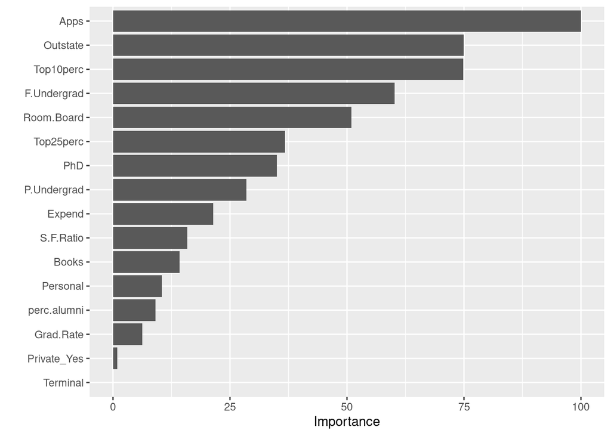

```r
vip(object = lm_fit, num_features = 20, method = "model")
```

### —————————————————————————-

## Question 2

For this question, you will work with the **banknote.rds** dataset. Load the dataset using the following code.

```r
banknote <- readRDS("banknote.rds")
```

The task is to predict whether a banknote is `authentic` or not (“Yes”/“No” variable) based on a number of measures taken from banknote images: `variance`, `skewness`, `kurtosis`, and `entropy` of wavelet transformed images.

Compare the performance (in terms of **Accuracy**) of the following two models:

- Logistic regression;
- $K$-NN classifier with optimal $K$ chosen by CV. Consider the grid of possible $K$ values given below.

**Perform the following tasks.**

- Investigate the dataset and complete any necessary tasks.

```r
summary(banknote) # all numeric except authentic
```

```
##     variance          skewness          kurtosis          entropy
##  Min.   :-7.0421   Min.   :-13.773   Min.   :-5.2861   Min.   :-8.5482
##  1st Qu.:-1.7976   1st Qu.: -1.862   1st Qu.:-1.5572   1st Qu.:-2.3931
##  Median : 0.4957   Median :  2.249   Median : 0.6286   Median :-0.5996
##  Mean   : 0.4382   Mean   :  1.795   Mean   : 1.3621   Mean   :-1.1793
##  3rd Qu.: 2.8297   3rd Qu.:  6.642   3rd Qu.: 3.0895   3rd Qu.: 0.4003
##  Max.   : 6.8248   Max.   : 12.952   Max.   :17.9274   Max.   : 2.4495
##  NA's   :203       NA's   :191       NA's   :179       NA's   :204
##  authentic
##  No :762
##  Yes:610
##
##
##
##
##
```

```r
sum(is.na(banknote)) # well crap there are NAs in there... yay... in everything except authentic
```

```
## [1] 777
```

```r
nearZeroVar(banknote, saveMetrics = TRUE)   # check which predictors are zv/nzv, so yay there are none
```

```
##           freqRatio percentUnique zeroVar   nzv
## variance   1.333333    83.4548105   FALSE FALSE
## skewness   1.000000    79.2274052   FALSE FALSE
## kurtosis   1.250000    81.1953353   FALSE FALSE
## entropy    1.250000    73.6151603   FALSE FALSE
## authentic  1.249180     0.1457726   FALSE FALSE
```

- Split the data into training and test sets (80-20).

```r
set.seed(333)

# create partition
ti <- createDataPartition(y = banknote$authentic, p = 0.8, list = FALSE)

# train and test
bn_train <- banknote[ti,]
bn_test <- banknote[-ti,]
```

- Perform required data preprocessing and create the blueprint. If using `step_dummy()`, set `one_hot = FALSE`. Prepare the blueprint on the training data. Obtain the modified training and test datasets. **Explain the blueprint steps that you use.**

```r
set.seed(333)

# prep the recipe
bn_recipe <- recipe(authentic ~ ., data = bn_train)

# create blueprint by using the step_center to center all numeric, the step_scale to scale all numeric, and step_impute_mean to fill in all the NAs.
blueprint <- bn_recipe %>%
  step_impute_mean(entropy, kurtosis, skewness, variance) %>%
  step_center(all_numeric(), -all_outcomes()) %>%
  step_scale(all_numeric(), -all_outcomes())

# prepare and apply blueprint to test and training data
prepare <- prep(blueprint, data = bn_train)
baked_train <- bake(prepare, new_data = bn_train)
baked_test <- bake(prepare, new_data = bn_train)
```

- Implement 5-fold CV repeated 5 times for each of the models above. Use `metric = "Accuracy"`.

```r
# write your R code here
set.seed(333)

# cv stuff
cv_specs <- trainControl(method = "repeatedcv", number = 5, repeats = 5)

# lm stuff
log_cv <- train(blueprint,
                data = bn_train,
                method = "glm",
                family = "binomial",
                trControl = cv_specs,
                metric = "Accuracy")

# knn stuff
k_grid <- expand.grid(k = seq(1, 101, by = 10))
knn_fit <- train(blueprint,
                  data = bn_train,
                  method = "knn",
                  trControl = cv_specs,
                  tuneGrid = k_grid,
                  metric = "Accuracy")
```

- Report the optimal CV Accuracy for each model. Report the optimal value of $K$ for the $K$-NN classifier. Which model performs better in this situation?

```r
# best optimal CV Accuracy for LRM
log_cv$results$Accuracy
```

```
## [1] 0.9012827
```

```r
# best optimal CV Accuracy for KNN:
max(knn_fit$results$Accuracy)
```

```
## [1] 0.9488178
```

```r
# k for knn
knn_fit$bestTune$k
```

```
## [1] 1
```

```
knn_fit was better because it had a higher accuracy
```

- Finally, with the optimal model, obtain class label predictions on the test set (use threshold of 0.5). Create the corresponding confusion matrix and report the test set accuracy.

```r
# build final model, get predictions on test data, and create confusion matric to calculate test Accuracy
final_model <- knn3(authentic ~ ., data = baked_train, k = knn_fit$bestTune$k)
final_preds <- predict(object = final_model, newdata = baked_test, type = "class")

confusionMatrix(data = relevel(final_preds, ref = "Yes"), reference = relevel(baked_test$authentic, ref = "Yes"))
```

```
## Confusion Matrix and Statistics
##
##           Reference
## Prediction Yes  No
##        Yes 488   0
##        No    0 610
##
##                Accuracy : 1
##                  95% CI : (0.9966, 1)
##     No Information Rate : 0.5556
##     P-Value [Acc > NIR] : < 2.2e-16
##
##                   Kappa : 1
##
##  Mcnemar's Test P-Value : NA
##
##             Sensitivity : 1.0000
##             Specificity : 1.0000
##          Pos Pred Value : 1.0000
##          Neg Pred Value : 1.0000
##              Prevalence : 0.4444
##          Detection Rate : 0.4444
##    Detection Prevalence : 0.4444
##       Balanced Accuracy : 1.0000
##
##        'Positive' Class : Yes
##
```

### —————————————————————————-